# BankPrediction

Marc-Antoine Gosselin

11/5/2018

# Bank Predictions

To run this code, users should have the following packages installed:

```r
install.packages("caret")
install.packages("tidyverse")
install.packages("purrr")
install.pacakges("corrplot")
install.packages("VIM")
install.packages("dummies")
install.packages("rpart")
```

## Data Exploration

```r
head(bank)
```

```
##   age       job marital   education default housing loan   contact month
## 1  56 housemaid married    basic.4y      no      no   no telephone   may
## 2  57  services married high.school unknown      no   no telephone   may
## 3  37  services married high.school      no     yes   no telephone   may
## 4  40    admin. married    basic.6y      no      no   no telephone   may
## 5  56  services married high.school      no      no  yes telephone   may
## 6  45  services married    basic.9y unknown      no   no telephone   may
##   day_of_week duration campaign pdays previous    poutcome emp.var.rate
## 1         mon      261        1   999        0 nonexistent          1.1
## 2         mon      149        1   999        0 nonexistent          1.1
## 3         mon      226        1   999        0 nonexistent          1.1
## 4         mon      151        1   999        0 nonexistent          1.1
## 5         mon      307        1   999        0 nonexistent          1.1
## 6         mon      198        1   999        0 nonexistent          1.1
##   cons.price.idx cons.conf.idx euribor3m nr.employed  y
## 1         93.994         -36.4     4.857        5191 no
## 2         93.994         -36.4     4.857        5191 no
## 3         93.994         -36.4     4.857        5191 no
## 4         93.994         -36.4     4.857        5191 no
## 5         93.994         -36.4     4.857        5191 no
## 6         93.994         -36.4     4.857        5191 no
```

```r
sum(bank$y == "yes") / nrow(bank) # for reference in prediction validation
```

```
## [1] 0.1126521
```

Two variables are worrisome: pdays because 999 is an imputed value for NA, and duration since the dataset’s readme mentions it “should be discarded if the intention is to have a realistic predictive model”. The readme file also mentions: “Missing Attribute Values: There are several missing values in some categorical attributes, all coded with the”unknown" label. These missing values can be treated as a possible class label or using deletion or imputation techniques". I will investigate treating the ‘unknown’ variable as a category, and the imputation techniques.

```
##            age            job        marital      education        default
##    0.000000000    0.007647719    0.001881582    0.042760463    0.206822251
##        housing           loan        contact          month    day_of_week
##    0.024157082    0.024157082    0.000000000    0.000000000    0.000000000
##       duration       campaign          pdays       previous       poutcome
##    0.000000000    0.000000000    0.963309156    0.000000000    0.000000000
##   emp.var.rate cons.price.idx  cons.conf.idx      euribor3m    nr.employed
##    0.000000000    0.000000000    0.000000000    0.000000000    0.000000000
##              y
##    0.000000000
```

```
##            age            job        marital      education        default
##             77             12              4              8              3
##        housing           loan        contact          month    day_of_week
##              3              3              2             10              5
##       duration       campaign          pdays       previous       poutcome
##           1464             42             27              7              3
##   emp.var.rate cons.price.idx  cons.conf.idx      euribor3m    nr.employed
##             10             26             26            313             11
##              y
##              2
```

We’ll remove pdays because it has less than 4% non NAs, and duration as recommended in readme.

Now that we have explored and cleaned our data a little, we could proceed to impute missing values. The following code imputes missing values using the kNN imputation technique. However, the techinque takes several minutes to run and only barely improves our modeling accuracy. If you would like to impute the missing values nonetheless, you can change “eval = FALSE” to “eval = TRUE” in the markdown code chunk titled “kNN Imputation” before knitting it.

```r
bank$pdays <- ifelse(bank$pdays == 999, NA, bank$pdays)
bank[bank == "unknown"] = NA

library(VIM)
bank <- kNN(bank, variable = c("job", "marital", "education", "default", "housing", "loan"), imp_var = FALSE)

# For bank_test prediction
bank_test$pdays <- ifelse(bank_test$pdays == 999, NA, bank_test$pdays)
bank_test[bank_test == "unknown"] = NA
bank_test <- subset(bank_test, select = c(-pdays, -duration))
bank_test <- kNN(bank_test, variable = c("job", "marital", "education", "default", "housing", "loan"), imp_var = FALSE)
```

Let’s look into the collinearity of the variables.

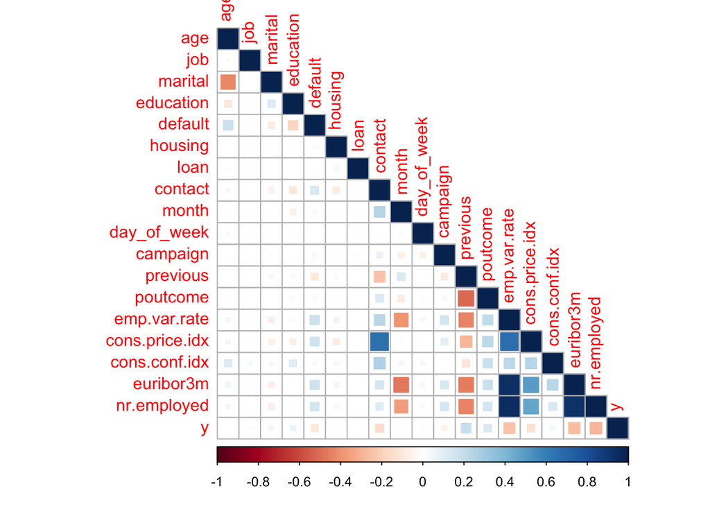

We can see some collinearity between some of the variables. Since we also have a good number of variables, our dataset appears to be a good candidate for PCA. In fact, modeling without PCA leads to difficult problems.

# Pre-processing for PCA

PCA only manages numerical data and is an unsupervised technique so we must remove the dependent variable y and convert non-numeric variables into dummy variables.

```r
#removing the response variable
vars <- subset(bank, select = -y)

# Converting factor class variables into dummies for PCA
library(dummies)

str(vars)
```

```
## 'data.frame':    32951 obs. of  18 variables:
##  $ age           : int  56 57 37 40 56 45 41 24 25 29 ...
##  $ job           : Factor w/ 12 levels "admin.","blue-collar",..: 4 8 8 1 8 8 2 10 8 2 ...
##  $ marital       : Factor w/ 4 levels "divorced","married",..: 2 2 2 2 2 2 2 3 3 3 ...
##  $ education     : Factor w/ 8 levels "basic.4y","basic.6y",..: 1 4 4 2 4 3 8 6 4 4 ...
##  $ default       : Factor w/ 3 levels "no","unknown",..: 1 2 1 1 1 2 2 1 1 1 ...
##  $ housing       : Factor w/ 3 levels "no","unknown",..: 1 1 3 1 1 1 1 3 3 1 ...
##  $ loan          : Factor w/ 3 levels "no","unknown",..: 1 1 1 1 3 1 1 1 1 3 ...
##  $ contact       : Factor w/ 2 levels "cellular","telephone": 2 2 2 2 2 2 2 2 2 2 ...
##  $ month         : Factor w/ 10 levels "apr","aug","dec",..: 7 7 7 7 7 7 7 7 7 7 ...
##  $ day_of_week   : Factor w/ 5 levels "fri","mon","thu",..: 2 2 2 2 2 2 2 2 2 2 ...
##  $ campaign      : int  1 1 1 1 1 1 1 1 1 1 ...
##  $ previous      : int  0 0 0 0 0 0 0 0 0 0 ...
##  $ poutcome      : Factor w/ 3 levels "failure","nonexistent",..: 2 2 2 2 2 2 2 2 2 2 ...
##  $ emp.var.rate  : num  1.1 1.1 1.1 1.1 1.1 1.1 1.1 1.1 1.1 1.1 ...
##  $ cons.price.idx: num  94 94 94 94 94 ...
##  $ cons.conf.idx : num  -36.4 -36.4 -36.4 -36.4 -36.4 -36.4 -36.4 -36.4 -36.4 -36.4 ...
##  $ euribor3m     : num  4.86 4.86 4.86 4.86 4.86 ...
##  $ nr.employed   : num  5191 5191 5191 5191 5191 ...
```

```r
dummy_vars <- dummy.data.frame(vars, names = c("job", "marital", "education", "default", "housing", "loan", "contact", "month", "day_of_week", "poutcome"), drop = FALSE)
```

#PCA

```r
components <- prcomp(dummy_vars, scale = T)
```

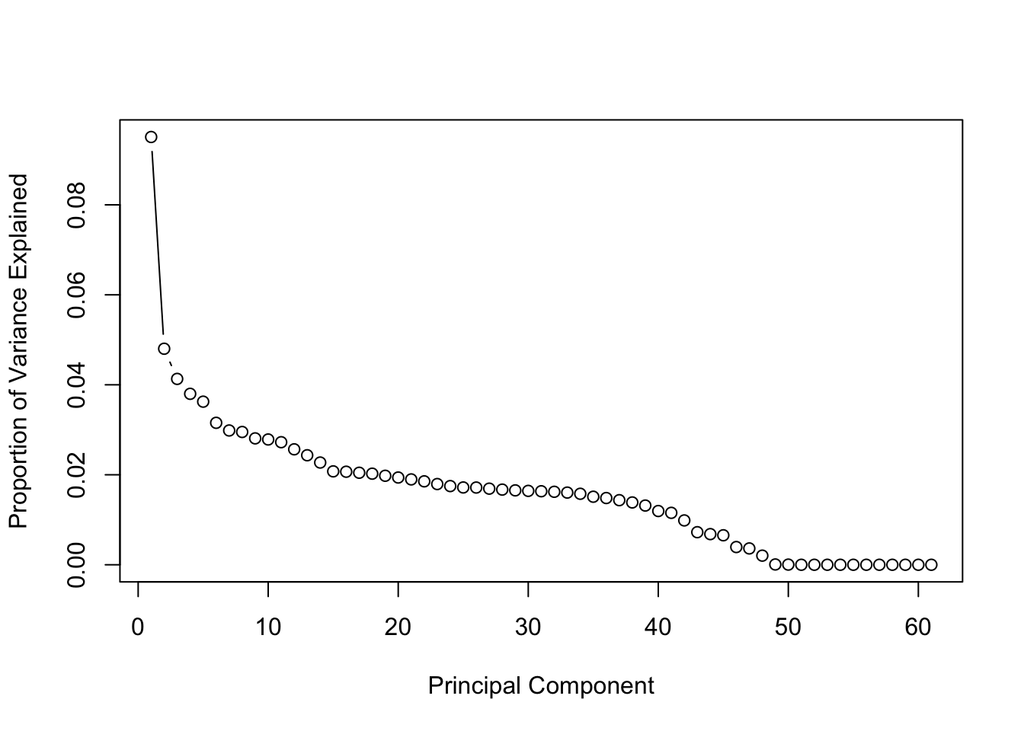

```r
std_dev <- components$sdev
pr_var <- std_dev^2
prop_varex <- pr_var/sum(pr_var)
plot(prop_varex, xlab = "Principal Component",
     ylab = "Proportion of Variance Explained",
     type = "b")
```

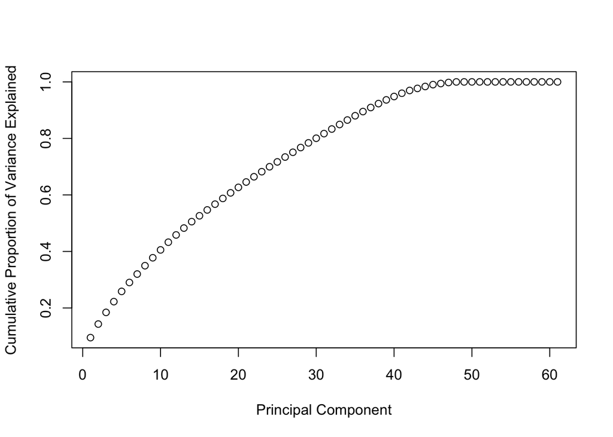

```r
# Cumulative scree plot
plot(cumsum(prop_varex), xlab = "Principal Component",
     ylab = "Cumulative Proportion of Variance Explained",
     type = "b")
```

Looking at the scree plots, it is not obvious where we should make the cutoff for analysis. Here we will take the 40 first components leaving us a good margin to guard against overfitting.

```r
# Adding back the response variable
bank_tr_predict <- data.frame(y = bank$y, components$x)

# We are interested in first 40 PCAs (from scree plot)
bank_tr_predict <- bank_tr_predict[,1:41] # 41 counting y col
```

```r
library(caret)
control <- trainControl(method="cv", number=10) # K-fold Cross validation

# Run a model
fit.lda <- train(y ~ .,
                 data = bank_tr_predict,
                 method = "lda",
                 metric = "Accuracy",
                 trControl = control)
fit.cart <- train(y ~ .,
                  data = bank_tr_predict,
                  method = "rpart",
                  metric = "Accuracy",
                  trControl = control)
fit.knn <- train(y ~ .,
                 data = bank_tr_predict,
                 method = "knn",
                 metric = "Accuracy",
                 trControl = control)

# The SVM and Random Forest techniques are too complex for my computer.

(results <- resamples(list(lda = fit.lda,
                           cart = fit.cart,
                           knn = fit.knn)))
```

```
##
## Call:
## resamples.default(x = list(lda = fit.lda, cart = fit.cart, knn = fit.knn))
##
## Models: lda, cart, knn
## Number of resamples: 10
## Performance metrics: Accuracy, Kappa
## Time estimates for: everything, final model fit
```

```r
summary(results)
```

```
##
## Call:
## summary.resamples(object = results)
##
## Models: lda, cart, knn
## Number of resamples: 10
##
## Accuracy
##           Min.   1st Qu.    Median      Mean   3rd Qu.      Max. NA's
## lda  0.8831563 0.8858204 0.8884674 0.8889260 0.8916540 0.8974203    0
## cart 0.8898331 0.8942337 0.8957354 0.8953295 0.8979746 0.8989378    0
## knn  0.8889226 0.8908194 0.8938107 0.8936908 0.8951442 0.8998483    0
##
## Kappa
##           Min.   1st Qu.    Median      Mean   3rd Qu.      Max. NA's
## lda  0.2861294 0.3236075 0.3262117 0.3303879 0.3486279 0.3563416    0
## cart 0.1616334 0.1884225 0.2144799 0.2145104 0.2434619 0.2682054    0
## knn  0.2499944 0.2733707 0.2906431 0.2894462 0.3015664 0.3301468    0
```

```r
# Formatting bank_test
bank_test <- read.csv("bank_testdata.csv")
library(tidyverse)

bank_test <- subset(bank_test, select = c(-pdays, -duration))
bank_test <- select(bank_test, -y)
levels(bank_test$default) <- c("yes", "no", "unknown")
test_dummy <- dummy.data.frame(bank_test, names = c("job", "marital", "education", "default", "housing", "loan", "contact", "month", "day_of_week", "poutcome"), drop = FALSE)

# Run bank_test obs. through PCA
pred <- predict(components, newdata = test_dummy)
pred <- as.data.frame(pred)

# Select the first 40 components
pred <- pred[,1:40]

# Make prediction for bank_test
prediction <- predict(fit.cart, pred)
prediction <- as.data.frame(prediction)
bank_prediction <- cbind(bank_test, prediction)

sum(bank_prediction$prediction == "yes") /nrow(prediction)
```

```
## [1] 0.09044555
```

```r
sum(bank$y == "yes") / nrow(bank) # for reference in prediction validation
```

```
## [1] 0.1126521
```

We predict 745 of the obs. will have y = “yes”. This is close to the 0.1126521 probability of y being “yes” from the training dataset so we are comfident in our prediction.